# Risk Factor Analysis

## Outcome Variable

**Outcome Variable:** sstunted

## Predictor Variables

**Intervention Variable:** mhtcm

**Adjustment Set:**

unadjusted

## Stratifying Variables

The analysis was stratified on these variable(s):

- agecat
- studyid

The following strata were considered:

- agecat: 12 months, studyid: ki0047075b-MAL-ED
- agecat: 12 months, studyid: ki1000304b-SAS-FoodSuppl
- agecat: 12 months, studyid: ki1017093-NIH-Birth
- agecat: 12 months, studyid: ki1017093b-PROVIDE
- agecat: 12 months, studyid: ki1017093c-NIH-Crypto
- agecat: 12 months, studyid: ki1066203-TanzaniaChild2
- agecat: 12 months, studyid: ki1101329-Keneba
- agecat: 12 months, studyid: ki1112895-Guatemala BSC
- agecat: 12 months, studyid: ki1126311-ZVITAMBO
- agecat: 12 months, studyid: ki1135781-COHORTS
- agecat: 12 months, studyid: ki1148112-LCNI-5
- agecat: 18 months, studyid: ki0047075b-MAL-ED
- agecat: 18 months, studyid: ki1000304b-SAS-FoodSuppl
- agecat: 18 months, studyid: ki1017093-NIH-Birth
- agecat: 18 months, studyid: ki1017093b-PROVIDE
- agecat: 18 months, studyid: ki1017093c-NIH-Crypto
- agecat: 18 months, studyid: ki1066203-TanzaniaChild2
- agecat: 18 months, studyid: ki1101329-Keneba
- agecat: 18 months, studyid: ki1126311-ZVITAMBO
- agecat: 18 months, studyid: ki1135781-COHORTS
- agecat: 18 months, studyid: ki1148112-LCNI-5
- agecat: 24 months, studyid: ki0047075b-MAL-ED
- agecat: 24 months, studyid: ki1017093-NIH-Birth
- agecat: 24 months, studyid: ki1017093b-PROVIDE
- agecat: 24 months, studyid: ki1017093c-NIH-Crypto
- agecat: 24 months, studyid: ki1066203-TanzaniaChild2
- agecat: 24 months, studyid: ki1101329-Keneba
- agecat: 24 months, studyid: ki1126311-ZVITAMBO
- agecat: 24 months, studyid: ki1135781-COHORTS
- agecat: 24 months, studyid: ki1148112-LCNI-5
- agecat: 3 months, studyid: ki0047075b-MAL-ED
- agecat: 3 months, studyid: ki1000304b-SAS-FoodSuppl
- agecat: 3 months, studyid: ki1017093-NIH-Birth
- agecat: 3 months, studyid: ki1017093b-PROVIDE
- agecat: 3 months, studyid: ki1017093c-NIH-Crypto
- agecat: 3 months, studyid: ki1066203-TanzaniaChild2
- agecat: 3 months, studyid: ki1101329-Keneba
- agecat: 3 months, studyid: ki1112895-Guatemala BSC
- agecat: 3 months, studyid: ki1126311-ZVITAMBO
- agecat: 3 months, studyid: ki1135781-COHORTS
- agecat: 6 months, studyid: ki0047075b-MAL-ED
- agecat: 6 months, studyid: ki1000304b-SAS-FoodSuppl
- agecat: 6 months, studyid: ki1017093-NIH-Birth
- agecat: 6 months, studyid: ki1017093b-PROVIDE
- agecat: 6 months, studyid: ki1017093c-NIH-Crypto
- agecat: 6 months, studyid: ki1066203-TanzaniaChild2
- agecat: 6 months, studyid: ki1101329-Keneba
- agecat: 6 months, studyid: ki1112895-Guatemala BSC
- agecat: 6 months, studyid: ki1126311-ZVITAMBO
- agecat: 6 months, studyid: ki1135781-COHORTS
- agecat: 6 months, studyid: ki1148112-LCNI-5
- agecat: 9 months, studyid: ki0047075b-MAL-ED
- agecat: 9 months, studyid: ki1000304b-SAS-FoodSuppl
- agecat: 9 months, studyid: ki1017093-NIH-Birth
- agecat: 9 months, studyid: ki1017093b-PROVIDE
- agecat: 9 months, studyid: ki1017093c-NIH-Crypto
- agecat: 9 months, studyid: ki1066203-TanzaniaChild2
- agecat: 9 months, studyid: ki1101329-Keneba
- agecat: 9 months, studyid: ki1112895-Guatemala BSC
- agecat: 9 months, studyid: ki1126311-ZVITAMBO
- agecat: 9 months, studyid: ki1135781-COHORTS
- agecat: 9 months, studyid: ki1148112-LCNI-5
- agecat: Birth, studyid: ki0047075b-MAL-ED
- agecat: Birth, studyid: ki1017093-NIH-Birth
- agecat: Birth, studyid: ki1017093c-NIH-Crypto
- agecat: Birth, studyid: ki1101329-Keneba
- agecat: Birth, studyid: ki1126311-ZVITAMBO
- agecat: Birth, studyid: ki1135781-COHORTS

### Dropped Strata

Some strata were dropped due to rare outcomes:

- agecat: Birth, studyid: ki0047075b-MAL-ED
- agecat: Birth, studyid: ki1017093-NIH-Birth
- agecat: Birth, studyid: ki1017093c-NIH-Crypto
- agecat: Birth, studyid: ki1101329-Keneba
- agecat: Birth, studyid: ki1126311-ZVITAMBO
- agecat: Birth, studyid: ki1135781-COHORTS
- agecat: 3 months, studyid: ki1000304b-SAS-FoodSuppl
- agecat: 3 months, studyid: ki1017093-NIH-Birth
- agecat: 3 months, studyid: ki1017093b-PROVIDE
- agecat: 3 months, studyid: ki1017093c-NIH-Crypto
- agecat: 3 months, studyid: ki1066203-TanzaniaChild2
- agecat: 3 months, studyid: ki1112895-Guatemala BSC
- agecat: 3 months, studyid: ki1135781-COHORTS
- agecat: 6 months, studyid: ki0047075b-MAL-ED
- agecat: 6 months, studyid: ki1000304b-SAS-FoodSuppl
- agecat: 6 months, studyid: ki1017093-NIH-Birth
- agecat: 6 months, studyid: ki1017093b-PROVIDE
- agecat: 6 months, studyid: ki1017093c-NIH-Crypto
- agecat: 6 months, studyid: ki1066203-TanzaniaChild2
- agecat: 6 months, studyid: ki1101329-Keneba
- agecat: 6 months, studyid: ki1112895-Guatemala BSC
- agecat: 6 months, studyid: ki1135781-COHORTS
- agecat: 6 months, studyid: ki1148112-LCNI-5
- agecat: 9 months, studyid: ki1000304b-SAS-FoodSuppl
- agecat: 9 months, studyid: ki1017093-NIH-Birth
- agecat: 9 months, studyid: ki1017093b-PROVIDE
- agecat: 9 months, studyid: ki1017093c-NIH-Crypto
- agecat: 9 months, studyid: ki1066203-TanzaniaChild2
- agecat: 9 months, studyid: ki1112895-Guatemala BSC
- agecat: 9 months, studyid: ki1135781-COHORTS
- agecat: 9 months, studyid: ki1148112-LCNI-5
- agecat: 12 months, studyid: ki1000304b-SAS-FoodSuppl
- agecat: 12 months, studyid: ki1017093-NIH-Birth
- agecat: 12 months, studyid: ki1017093b-PROVIDE
- agecat: 12 months, studyid: ki1017093c-NIH-Crypto
- agecat: 12 months, studyid: ki1066203-TanzaniaChild2
- agecat: 12 months, studyid: ki1112895-Guatemala BSC
- agecat: 12 months, studyid: ki1148112-LCNI-5
- agecat: 18 months, studyid: ki1000304b-SAS-FoodSuppl
- agecat: 18 months, studyid: ki1017093-NIH-Birth
- agecat: 18 months, studyid: ki1017093b-PROVIDE
- agecat: 18 months, studyid: ki1017093c-NIH-Crypto
- agecat: 18 months, studyid: ki1066203-TanzaniaChild2
- agecat: 18 months, studyid: ki1126311-ZVITAMBO
- agecat: 24 months, studyid: ki1017093-NIH-Birth
- agecat: 24 months, studyid: ki1017093b-PROVIDE
- agecat: 24 months, studyid: ki1017093c-NIH-Crypto
- agecat: 24 months, studyid: ki1066203-TanzaniaChild2
- agecat: 24 months, studyid: ki1126311-ZVITAMBO

## Methods Detail

We’re interested in the causal parameters $E[Y_a]$ for all values of $a \in \mathcal{A}$. These parameters represent the mean outcome if, possibly contrary to fact, we intervened to set all units to have $A=a$. Under the randomization and positivity assumptions, these are identified by the statistical parameters $\psi_a=E_W[E_{Y|A,W}(Y|A=a,W)]$. In addition, we’re interested in the mean of $Y$, $E[Y]$ under no intervention (the observed mean). We will estimate these parameters by using SuperLearner to fit the relevant likelihood factors – $E_{Y|A,W}(Y|A=a,W)$ and $p(A=a|W)$, and then updating our likelihood fit using a joint TMLE.

For unadjusted analyses ($W=\{\}$), initial likelihoods were estimated using Lrnr_glm to estimate the simple $E(Y|A)$ and Lrnr_mean to estimate $p(A)$. For adjusted analyses, a small library containing Lrnr_glmnet, Lrnr_xgboost, and Lrnr_mean was used.

Having estimated these parameters, we will then use the delta method to estimate relative risks and attributable risks relative to a prespecified baseline level of $A$.

# Results Detail

## Results Plots

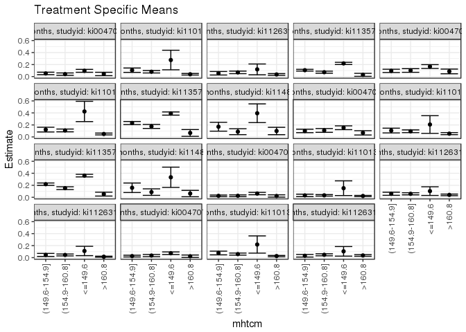

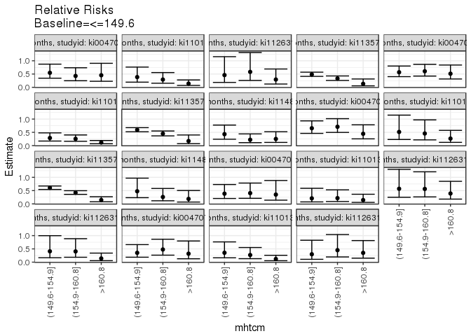

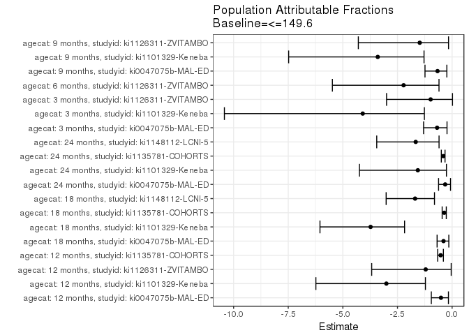

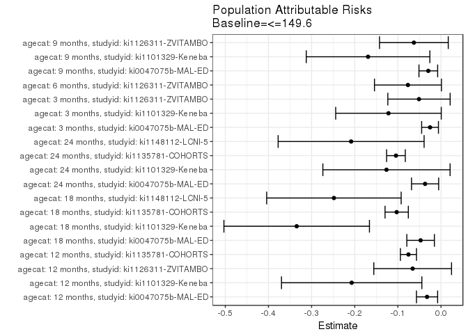

## Data Summary

| agecat | studyid | A | n | nA | nAY0 | nAY1 |
| --- | --- | --- | --- | --- | --- | --- |
| Birth | ki0047075b-MAL-ED | <=149.6 | 1425 | 508 | 486 | 22 |
| Birth | ki0047075b-MAL-ED | (149.6-154.9] | 1425 | 405 | 394 | 11 |
| Birth | ki0047075b-MAL-ED | (154.9-160.8] | 1425 | 334 | 327 | 7 |
| Birth | ki0047075b-MAL-ED | >160.8 | 1425 | 178 | 176 | 2 |
| Birth | ki1000304b-SAS-FoodSuppl | <=149.6 | 0 | 0 | 0 | 0 |
| Birth | ki1000304b-SAS-FoodSuppl | (149.6-154.9] | 0 | 0 | 0 | 0 |
| Birth | ki1000304b-SAS-FoodSuppl | (154.9-160.8] | 0 | 0 | 0 | 0 |
| Birth | ki1000304b-SAS-FoodSuppl | >160.8 | 0 | 0 | 0 | 0 |
| Birth | ki1017093-NIH-Birth | <=149.6 | 28 | 14 | 14 | 0 |
| Birth | ki1017093-NIH-Birth | (149.6-154.9] | 28 | 7 | 7 | 0 |
| Birth | ki1017093-NIH-Birth | (154.9-160.8] | 28 | 7 | 7 | 0 |
| Birth | ki1017093-NIH-Birth | >160.8 | 28 | 0 | 0 | 0 |
| Birth | ki1017093b-PROVIDE | <=149.6 | 0 | 0 | 0 | 0 |
| Birth | ki1017093b-PROVIDE | (149.6-154.9] | 0 | 0 | 0 | 0 |
| Birth | ki1017093b-PROVIDE | (154.9-160.8] | 0 | 0 | 0 | 0 |
| Birth | ki1017093b-PROVIDE | >160.8 | 0 | 0 | 0 | 0 |
| Birth | ki1017093c-NIH-Crypto | <=149.6 | 27 | 14 | 14 | 0 |
| Birth | ki1017093c-NIH-Crypto | (149.6-154.9] | 27 | 9 | 8 | 1 |
| Birth | ki1017093c-NIH-Crypto | (154.9-160.8] | 27 | 3 | 3 | 0 |
| Birth | ki1017093c-NIH-Crypto | >160.8 | 27 | 1 | 1 | 0 |
| Birth | ki1066203-TanzaniaChild2 | <=149.6 | 0 | 0 | 0 | 0 |
| Birth | ki1066203-TanzaniaChild2 | (149.6-154.9] | 0 | 0 | 0 | 0 |
| Birth | ki1066203-TanzaniaChild2 | (154.9-160.8] | 0 | 0 | 0 | 0 |
| Birth | ki1066203-TanzaniaChild2 | >160.8 | 0 | 0 | 0 | 0 |
| Birth | ki1101329-Keneba | <=149.6 | 1429 | 23 | 21 | 2 |
| Birth | ki1101329-Keneba | (149.6-154.9] | 1429 | 220 | 213 | 7 |
| Birth | ki1101329-Keneba | (154.9-160.8] | 1429 | 548 | 543 | 5 |
| Birth | ki1101329-Keneba | >160.8 | 1429 | 638 | 626 | 12 |
| Birth | ki1112895-Guatemala BSC | <=149.6 | 0 | 0 | 0 | 0 |
| Birth | ki1112895-Guatemala BSC | (149.6-154.9] | 0 | 0 | 0 | 0 |

[output cut: 278 more lines]

## Results Table

### Parameter: TSM

| agecat | studyid | intervention_level | baseline_level | estimate | ci_lower | ci_upper |
| --- | --- | --- | --- | --- | --- | --- |
| 3 months | ki0047075b-MAL-ED | <=149.6 | NA | 0.0622896 | 0.0428485 | 0.0817306 |
| 3 months | ki0047075b-MAL-ED | (149.6-154.9] | NA | 0.0239521 | 0.0105596 | 0.0373445 |
| 3 months | ki0047075b-MAL-ED | (154.9-160.8] | NA | 0.0252294 | 0.0105051 | 0.0399536 |
| 3 months | ki0047075b-MAL-ED | >160.8 | NA | 0.0218341 | 0.0029007 | 0.0407674 |
| 3 months | ki1101329-Keneba | <=149.6 | NA | 0.1515152 | 0.0291514 | 0.2738789 |
| 3 months | ki1101329-Keneba | (149.6-154.9] | NA | 0.0316901 | 0.0113118 | 0.0520685 |
| 3 months | ki1101329-Keneba | (154.9-160.8] | NA | 0.0328084 | 0.0201572 | 0.0454596 |
| 3 months | ki1101329-Keneba | >160.8 | NA | 0.0218391 | 0.0121245 | 0.0315536 |
| 3 months | ki1126311-ZVITAMBO | <=149.6 | NA | 0.1029412 | 0.0306956 | 0.1751868 |
| 3 months | ki1126311-ZVITAMBO | (149.6-154.9] | NA | 0.0586420 | 0.0330520 | 0.0842320 |
| 3 months | ki1126311-ZVITAMBO | (154.9-160.8] | NA | 0.0579710 | 0.0405299 | 0.0754121 |
| 3 months | ki1126311-ZVITAMBO | >160.8 | NA | 0.0402844 | 0.0270156 | 0.0535531 |
| 6 months | ki1126311-ZVITAMBO | <=149.6 | NA | 0.1111111 | 0.0334858 | 0.1887364 |
| 6 months | ki1126311-ZVITAMBO | (149.6-154.9] | NA | 0.0454545 | 0.0203209 | 0.0705882 |
| 6 months | ki1126311-ZVITAMBO | (154.9-160.8] | NA | 0.0449775 | 0.0292445 | 0.0607105 |
| 6 months | ki1126311-ZVITAMBO | >160.8 | NA | 0.0155039 | 0.0067977 | 0.0242101 |
| 9 months | ki0047075b-MAL-ED | <=149.6 | NA | 0.0734767 | 0.0518213 | 0.0951321 |
| 9 months | ki0047075b-MAL-ED | (149.6-154.9] | NA | 0.0258621 | 0.0114155 | 0.0403086 |
| 9 months | ki0047075b-MAL-ED | (154.9-160.8] | NA | 0.0350877 | 0.0170278 | 0.0531476 |
| 9 months | ki0047075b-MAL-ED | >160.8 | NA | 0.0234742 | 0.0031352 | 0.0438131 |
| 9 months | ki1101329-Keneba | <=149.6 | NA | 0.2187500 | 0.0754790 | 0.3620210 |
| 9 months | ki1101329-Keneba | (149.6-154.9] | NA | 0.0774648 | 0.0463656 | 0.1085639 |
| 9 months | ki1101329-Keneba | (154.9-160.8] | NA | 0.0589888 | 0.0416784 | 0.0762991 |
| 9 months | ki1101329-Keneba | >160.8 | NA | 0.0260664 | 0.0153141 | 0.0368186 |
| 9 months | ki1126311-ZVITAMBO | <=149.6 | NA | 0.1052632 | 0.0255690 | 0.1849573 |
| 9 months | ki1126311-ZVITAMBO | (149.6-154.9] | NA | 0.0313725 | 0.0099702 | 0.0527749 |
| 9 months | ki1126311-ZVITAMBO | (154.9-160.8] | NA | 0.0476190 | 0.0309848 | 0.0642533 |
| 9 months | ki1126311-ZVITAMBO | >160.8 | NA | 0.0368852 | 0.0232272 | 0.0505433 |
| 12 months | ki0047075b-MAL-ED | <=149.6 | NA | 0.0956679 | 0.0711674 | 0.1201684 |
| 12 months | ki0047075b-MAL-ED | (149.6-154.9] | NA | 0.0524017 | 0.0319874 | 0.0728161 |
| 12 months | ki0047075b-MAL-ED | (154.9-160.8] | NA | 0.0409207 | 0.0212784 | 0.0605631 |
| 12 months | ki0047075b-MAL-ED | >160.8 | NA | 0.0434783 | 0.0156887 | 0.0712678 |
| 12 months | ki1101329-Keneba | <=149.6 | NA | 0.2758621 | 0.1131468 | 0.4385773 |
| 12 months | ki1101329-Keneba | (149.6-154.9] | NA | 0.1062271 | 0.0696659 | 0.1427883 |
| 12 months | ki1101329-Keneba | (154.9-160.8] | NA | 0.0805970 | 0.0599791 | 0.1012150 |
| 12 months | ki1101329-Keneba | >160.8 | NA | 0.0387016 | 0.0253403 | 0.0520629 |
| 12 months | ki1126311-ZVITAMBO | <=149.6 | NA | 0.1200000 | 0.0298959 | 0.2101041 |
| 12 months | ki1126311-ZVITAMBO | (149.6-154.9] | NA | 0.0553191 | 0.0260814 | 0.0845569 |
| 12 months | ki1126311-ZVITAMBO | (154.9-160.8] | NA | 0.0698529 | 0.0484257 | 0.0912802 |
| 12 months | ki1126311-ZVITAMBO | >160.8 | NA | 0.0352000 | 0.0207474 | 0.0496526 |
| 12 months | ki1135781-COHORTS | <=149.6 | NA | 0.2191423 | 0.2005984 | 0.2376861 |
| 12 months | ki1135781-COHORTS | (149.6-154.9] | NA | 0.1062425 | 0.0914440 | 0.1210410 |
| 12 months | ki1135781-COHORTS | (154.9-160.8] | NA | 0.0730594 | 0.0558245 | 0.0902942 |
| 12 months | ki1135781-COHORTS | >160.8 | NA | 0.0289017 | 0.0039348 | 0.0538687 |
| 18 months | ki0047075b-MAL-ED | <=149.6 | NA | 0.1673004 | 0.1353932 | 0.1992076 |
| 18 months | ki0047075b-MAL-ED | (149.6-154.9] | NA | 0.0950226 | 0.0676756 | 0.1223697 |
| 18 months | ki0047075b-MAL-ED | (154.9-160.8] | NA | 0.1013333 | 0.0707807 | 0.1318860 |
| 18 months | ki0047075b-MAL-ED | >160.8 | NA | 0.0858586 | 0.0468235 | 0.1248937 |
| 18 months | ki1101329-Keneba | <=149.6 | NA | 0.4242424 | 0.2555714 | 0.5929135 |
| 18 months | ki1101329-Keneba | (149.6-154.9] | NA | 0.1216730 | 0.0821529 | 0.1611931 |
| 18 months | ki1101329-Keneba | (154.9-160.8] | NA | 0.1081871 | 0.0849026 | 0.1314717 |
| 18 months | ki1101329-Keneba | >160.8 | NA | 0.0491803 | 0.0341254 | 0.0642353 |
| 18 months | ki1135781-COHORTS | <=149.6 | NA | 0.3898039 | 0.3630292 | 0.4165787 |
| 18 months | ki1135781-COHORTS | (149.6-154.9] | NA | 0.2315690 | 0.2061462 | 0.2569918 |
| 18 months | ki1135781-COHORTS | (154.9-160.8] | NA | 0.1750503 | 0.1416354 | 0.2084652 |
| 18 months | ki1135781-COHORTS | >160.8 | NA | 0.0666667 | 0.0102035 | 0.1231298 |
| 18 months | ki1148112-LCNI-5 | <=149.6 | NA | 0.3947368 | 0.2391063 | 0.5503674 |
| 18 months | ki1148112-LCNI-5 | (149.6-154.9] | NA | 0.1700000 | 0.0962734 | 0.2437266 |
| 18 months | ki1148112-LCNI-5 | (154.9-160.8] | NA | 0.0873016 | 0.0379444 | 0.1366587 |
| 18 months | ki1148112-LCNI-5 | >160.8 | NA | 0.0989011 | 0.0374787 | 0.1603235 |
| 24 months | ki0047075b-MAL-ED | <=149.6 | NA | 0.1527778 | 0.1213576 | 0.1841979 |
| 24 months | ki0047075b-MAL-ED | (149.6-154.9] | NA | 0.1000000 | 0.0712994 | 0.1287006 |
| 24 months | ki0047075b-MAL-ED | (154.9-160.8] | NA | 0.1084011 | 0.0766701 | 0.1401320 |
| 24 months | ki0047075b-MAL-ED | >160.8 | NA | 0.0680628 | 0.0323334 | 0.1037923 |
| 24 months | ki1101329-Keneba | <=149.6 | NA | 0.2068966 | 0.0594189 | 0.3543742 |
| 24 months | ki1101329-Keneba | (149.6-154.9] | NA | 0.1063830 | 0.0669498 | 0.1458161 |
| 24 months | ki1101329-Keneba | (154.9-160.8] | NA | 0.0944000 | 0.0714703 | 0.1173297 |
| 24 months | ki1101329-Keneba | >160.8 | NA | 0.0546985 | 0.0380025 | 0.0713944 |
| 24 months | ki1135781-COHORTS | <=149.6 | NA | 0.3609375 | 0.3394527 | 0.3824223 |
| 24 months | ki1135781-COHORTS | (149.6-154.9] | NA | 0.2183637 | 0.1987170 | 0.2380105 |
| 24 months | ki1135781-COHORTS | (154.9-160.8] | NA | 0.1523605 | 0.1292863 | 0.1754348 |
| 24 months | ki1135781-COHORTS | >160.8 | NA | 0.0529101 | 0.0209926 | 0.0848275 |
| 24 months | ki1148112-LCNI-5 | <=149.6 | NA | 0.3333333 | 0.1643608 | 0.5023058 |
| 24 months | ki1148112-LCNI-5 | (149.6-154.9] | NA | 0.1585366 | 0.0793488 | 0.2377244 |
| 24 months | ki1148112-LCNI-5 | (154.9-160.8] | NA | 0.0865385 | 0.0324112 | 0.1406657 |
| 24 months | ki1148112-LCNI-5 | >160.8 | NA | 0.0625000 | 0.0093671 | 0.1156329 |

### Parameter: E(Y)

| agecat | studyid | intervention_level | baseline_level | estimate | ci_lower | ci_upper |
| --- | --- | --- | --- | --- | --- | --- |
| 3 months | ki0047075b-MAL-ED | NA | NA | 0.0369318 | 0.0360847 | 0.0377789 |
| 3 months | ki1101329-Keneba | NA | NA | 0.0297589 | 0.0290116 | 0.0305061 |
| 3 months | ki1126311-ZVITAMBO | NA | NA | 0.0519211 | 0.0513353 | 0.0525069 |
| 6 months | ki1126311-ZVITAMBO | NA | NA | 0.0345023 | 0.0335394 | 0.0354651 |
| 9 months | ki0047075b-MAL-ED | NA | NA | 0.0440636 | 0.0430184 | 0.0451089 |
| 9 months | ki1101329-Keneba | NA | NA | 0.0496795 | 0.0483276 | 0.0510313 |
| 9 months | ki1126311-ZVITAMBO | NA | NA | 0.0424134 | 0.0417765 | 0.0430502 |
| 12 months | ki0047075b-MAL-ED | NA | NA | 0.0633540 | 0.0621911 | 0.0645169 |
| 12 months | ki1101329-Keneba | NA | NA | 0.0688099 | 0.0670810 | 0.0705388 |
| 12 months | ki1126311-ZVITAMBO | NA | NA | 0.0543329 | 0.0533098 | 0.0553560 |
| 12 months | ki1135781-COHORTS | NA | NA | 0.1437216 | 0.1418332 | 0.1456101 |
| 18 months | ki0047075b-MAL-ED | NA | NA | 0.1200519 | 0.1183383 | 0.1217655 |
| 18 months | ki1101329-Keneba | NA | NA | 0.0896785 | 0.0870858 | 0.0922713 |
| 18 months | ki1135781-COHORTS | NA | NA | 0.2870912 | 0.2836112 | 0.2905712 |
| 18 months | ki1148112-LCNI-5 | NA | NA | 0.1464789 | 0.1368318 | 0.1561260 |
| 24 months | ki0047075b-MAL-ED | NA | NA | 0.1159030 | 0.1144262 | 0.1173798 |
| 24 months | ki1101329-Keneba | NA | NA | 0.0805243 | 0.0791747 | 0.0818740 |
| 24 months | ki1135781-COHORTS | NA | NA | 0.2565401 | 0.2538807 | 0.2591994 |
| 24 months | ki1148112-LCNI-5 | NA | NA | 0.1250000 | 0.1159526 | 0.1340474 |

### Parameter: RR

| agecat | studyid | intervention_level | baseline_level | estimate | ci_lower | ci_upper |
| --- | --- | --- | --- | --- | --- | --- |
| 3 months | ki0047075b-MAL-ED | (149.6-154.9] | <=149.6 | 0.3845282 | 0.2026887 | 0.7295029 |
| 3 months | ki0047075b-MAL-ED | (154.9-160.8] | <=149.6 | 0.4050335 | 0.2089595 | 0.7850904 |
| 3 months | ki0047075b-MAL-ED | >160.8 | <=149.6 | 0.3505252 | 0.1394670 | 0.8809822 |
| 3 months | ki1101329-Keneba | (149.6-154.9] | <=149.6 | 0.2091549 | 0.0744950 | 0.5872313 |
| 3 months | ki1101329-Keneba | (154.9-160.8] | <=149.6 | 0.2165354 | 0.0884836 | 0.5299014 |
| 3 months | ki1101329-Keneba | >160.8 | <=149.6 | 0.1441379 | 0.0573269 | 0.3624085 |
| 3 months | ki1126311-ZVITAMBO | (149.6-154.9] | <=149.6 | 0.5696649 | 0.2492931 | 1.3017530 |
| 3 months | ki1126311-ZVITAMBO | (154.9-160.8] | <=149.6 | 0.5631470 | 0.2624229 | 1.2084866 |
| 3 months | ki1126311-ZVITAMBO | >160.8 | <=149.6 | 0.3913338 | 0.1802416 | 0.8496493 |
| 6 months | ki1126311-ZVITAMBO | (149.6-154.9] | <=149.6 | 0.4090909 | 0.1678330 | 0.9971541 |
| 6 months | ki1126311-ZVITAMBO | (154.9-160.8] | <=149.6 | 0.4047976 | 0.1853195 | 0.8842087 |
| 6 months | ki1126311-ZVITAMBO | >160.8 | <=149.6 | 0.1395349 | 0.0569389 | 0.3419450 |
| 9 months | ki0047075b-MAL-ED | (149.6-154.9] | <=149.6 | 0.3519765 | 0.1871633 | 0.6619214 |
| 9 months | ki0047075b-MAL-ED | (154.9-160.8] | <=149.6 | 0.4775353 | 0.2638871 | 0.8641572 |
| 9 months | ki0047075b-MAL-ED | >160.8 | <=149.6 | 0.3194778 | 0.1279314 | 0.7978187 |
| 9 months | ki1101329-Keneba | (149.6-154.9] | <=149.6 | 0.3541247 | 0.1642594 | 0.7634531 |
| 9 months | ki1101329-Keneba | (154.9-160.8] | <=149.6 | 0.2696629 | 0.1315627 | 0.5527256 |
| 9 months | ki1101329-Keneba | >160.8 | <=149.6 | 0.1191605 | 0.0549512 | 0.2583967 |
| 9 months | ki1126311-ZVITAMBO | (149.6-154.9] | <=149.6 | 0.2980392 | 0.1075670 | 0.8257864 |
| 9 months | ki1126311-ZVITAMBO | (154.9-160.8] | <=149.6 | 0.4523810 | 0.1965130 | 1.0413992 |
| 9 months | ki1126311-ZVITAMBO | >160.8 | <=149.6 | 0.3504098 | 0.1508535 | 0.8139488 |
| 12 months | ki0047075b-MAL-ED | (149.6-154.9] | <=149.6 | 0.5477466 | 0.3436417 | 0.8730788 |
| 12 months | ki0047075b-MAL-ED | (154.9-160.8] | <=149.6 | 0.4277373 | 0.2482543 | 0.7369831 |
| 12 months | ki0047075b-MAL-ED | >160.8 | <=149.6 | 0.4544709 | 0.2282807 | 0.9047798 |
| 12 months | ki1101329-Keneba | (149.6-154.9] | <=149.6 | 0.3850733 | 0.1945166 | 0.7623071 |
| 12 months | ki1101329-Keneba | (154.9-160.8] | <=149.6 | 0.2921642 | 0.1536056 | 0.5557083 |
| 12 months | ki1101329-Keneba | >160.8 | <=149.6 | 0.1402934 | 0.0708302 | 0.2778790 |
| 12 months | ki1126311-ZVITAMBO | (149.6-154.9] | <=149.6 | 0.4609929 | 0.1840401 | 1.1547180 |
| 12 months | ki1126311-ZVITAMBO | (154.9-160.8] | <=149.6 | 0.5821078 | 0.2586686 | 1.3099753 |
| 12 months | ki1126311-ZVITAMBO | >160.8 | <=149.6 | 0.2933333 | 0.1246507 | 0.6902842 |
| 12 months | ki1135781-COHORTS | (149.6-154.9] | <=149.6 | 0.4848106 | 0.4118995 | 0.5706279 |
| 12 months | ki1135781-COHORTS | (154.9-160.8] | <=149.6 | 0.3333878 | 0.2594819 | 0.4283437 |
| 12 months | ki1135781-COHORTS | >160.8 | <=149.6 | 0.1318857 | 0.0553648 | 0.3141677 |
| 18 months | ki0047075b-MAL-ED | (149.6-154.9] | <=149.6 | 0.5679761 | 0.4021507 | 0.8021792 |
| 18 months | ki0047075b-MAL-ED | (154.9-160.8] | <=149.6 | 0.6056970 | 0.4239507 | 0.8653572 |
| 18 months | ki0047075b-MAL-ED | >160.8 | <=149.6 | 0.5132002 | 0.3134501 | 0.8402435 |
| 18 months | ki1101329-Keneba | (149.6-154.9] | <=149.6 | 0.2868007 | 0.1716396 | 0.4792288 |
| 18 months | ki1101329-Keneba | (154.9-160.8] | <=149.6 | 0.2550125 | 0.1622624 | 0.4007793 |
| 18 months | ki1101329-Keneba | >160.8 | <=149.6 | 0.1159251 | 0.0701874 | 0.1914678 |
| 18 months | ki1135781-COHORTS | (149.6-154.9] | <=149.6 | 0.5940653 | 0.5219060 | 0.6762015 |
| 18 months | ki1135781-COHORTS | (154.9-160.8] | <=149.6 | 0.4490727 | 0.3666162 | 0.5500747 |
| 18 months | ki1135781-COHORTS | >160.8 | <=149.6 | 0.1710262 | 0.0731190 | 0.4000319 |
| 18 months | ki1148112-LCNI-5 | (149.6-154.9] | <=149.6 | 0.4306667 | 0.2396602 | 0.7739030 |
| 18 months | ki1148112-LCNI-5 | (154.9-160.8] | <=149.6 | 0.2211640 | 0.1110126 | 0.4406123 |
| 18 months | ki1148112-LCNI-5 | >160.8 | <=149.6 | 0.2505495 | 0.1200647 | 0.5228435 |
| 24 months | ki0047075b-MAL-ED | (149.6-154.9] | <=149.6 | 0.6545455 | 0.4598302 | 0.9317129 |
| 24 months | ki0047075b-MAL-ED | (154.9-160.8] | <=149.6 | 0.7095344 | 0.4961443 | 1.0147028 |
| 24 months | ki0047075b-MAL-ED | >160.8 | <=149.6 | 0.4455021 | 0.2535107 | 0.7828945 |
| 24 months | ki1101329-Keneba | (149.6-154.9] | <=149.6 | 0.5141844 | 0.2302477 | 1.1482659 |
| 24 months | ki1101329-Keneba | (154.9-160.8] | <=149.6 | 0.4562667 | 0.2148671 | 0.9688747 |
| 24 months | ki1101329-Keneba | >160.8 | <=149.6 | 0.2643759 | 0.1217487 | 0.5740893 |
| 24 months | ki1135781-COHORTS | (149.6-154.9] | <=149.6 | 0.6049905 | 0.5431209 | 0.6739079 |
| 24 months | ki1135781-COHORTS | (154.9-160.8] | <=149.6 | 0.4221244 | 0.3587324 | 0.4967184 |
| 24 months | ki1135781-COHORTS | >160.8 | <=149.6 | 0.1465906 | 0.0799559 | 0.2687584 |
| 24 months | ki1148112-LCNI-5 | (149.6-154.9] | <=149.6 | 0.4756098 | 0.2334433 | 0.9689920 |
| 24 months | ki1148112-LCNI-5 | (154.9-160.8] | <=149.6 | 0.2596154 | 0.1160598 | 0.5807363 |
| 24 months | ki1148112-LCNI-5 | >160.8 | <=149.6 | 0.1875000 | 0.0696854 | 0.5044996 |

### Parameter: PAR

| agecat | studyid | intervention_level | baseline_level | estimate | ci_lower | ci_upper |
| --- | --- | --- | --- | --- | --- | --- |
| 3 months | ki0047075b-MAL-ED | <=149.6 | NA | -0.0253577 | -0.0448173 | -0.0058982 |
| 3 months | ki1101329-Keneba | <=149.6 | NA | -0.1217563 | -0.2441223 | 0.0006097 |
| 3 months | ki1126311-ZVITAMBO | <=149.6 | NA | -0.0510201 | -0.1232681 | 0.0212279 |
| 6 months | ki1126311-ZVITAMBO | <=149.6 | NA | -0.0766088 | -0.1542401 | 0.0010224 |
| 9 months | ki0047075b-MAL-ED | <=149.6 | NA | -0.0294131 | -0.0510937 | -0.0077324 |
| 9 months | ki1101329-Keneba | <=149.6 | NA | -0.1690705 | -0.3123479 | -0.0257932 |
| 9 months | ki1126311-ZVITAMBO | <=149.6 | NA | -0.0628498 | -0.1425464 | 0.0168469 |
| 12 months | ki0047075b-MAL-ED | <=149.6 | NA | -0.0323138 | -0.0568419 | -0.0077857 |
| 12 months | ki1101329-Keneba | <=149.6 | NA | -0.2070521 | -0.3697766 | -0.0443277 |
| 12 months | ki1126311-ZVITAMBO | <=149.6 | NA | -0.0656671 | -0.1557770 | 0.0244428 |
| 12 months | ki1135781-COHORTS | <=149.6 | NA | -0.0754206 | -0.0940604 | -0.0567809 |
| 18 months | ki0047075b-MAL-ED | <=149.6 | NA | -0.0472485 | -0.0792017 | -0.0152953 |
| 18 months | ki1101329-Keneba | <=149.6 | NA | -0.3345639 | -0.5032549 | -0.1658730 |
| 18 months | ki1135781-COHORTS | <=149.6 | NA | -0.1027127 | -0.1297127 | -0.0757127 |
| 18 months | ki1148112-LCNI-5 | <=149.6 | NA | -0.2482580 | -0.4041872 | -0.0923287 |
| 24 months | ki0047075b-MAL-ED | <=149.6 | NA | -0.0368748 | -0.0683296 | -0.0054200 |
| 24 months | ki1101329-Keneba | <=149.6 | NA | -0.1263722 | -0.2738560 | 0.0211116 |
| 24 months | ki1135781-COHORTS | <=149.6 | NA | -0.1043974 | -0.1260462 | -0.0827487 |
| 24 months | ki1148112-LCNI-5 | <=149.6 | NA | -0.2083333 | -0.3775479 | -0.0391188 |

### Parameter: PAF

| agecat | studyid | intervention_level | baseline_level | estimate | ci_lower | ci_upper |
| --- | --- | --- | --- | --- | --- | --- |
| 3 months | ki0047075b-MAL-ED | <=149.6 | NA | -0.6866097 | -1.3063591 | -0.2333952 |
| 3 months | ki1101329-Keneba | <=149.6 | NA | -4.0914316 | -10.4220974 | -1.2695197 |
| 3 months | ki1126311-ZVITAMBO | <=149.6 | NA | -0.9826471 | -3.0001745 | 0.0173205 |
| 6 months | ki1126311-ZVITAMBO | <=149.6 | NA | -2.2204007 | -5.4798052 | -0.6005081 |
| 9 months | ki0047075b-MAL-ED | <=149.6 | NA | -0.6675129 | -1.2412003 | -0.2406742 |
| 9 months | ki1101329-Keneba | <=149.6 | NA | -3.4032258 | -7.4812294 | -1.2860362 |
| 9 months | ki1126311-ZVITAMBO | <=149.6 | NA | -1.4818384 | -4.2922453 | -0.1638769 |
| 12 months | ki0047075b-MAL-ED | <=149.6 | NA | -0.5100516 | -0.9520898 | -0.1681102 |
| 12 months | ki1101329-Keneba | <=149.6 | NA | -3.0090447 | -6.2350020 | -1.2214837 |
| 12 months | ki1126311-ZVITAMBO | <=149.6 | NA | -1.2086076 | -3.6807842 | -0.0421219 |
| 12 months | ki1135781-COHORTS | <=149.6 | NA | -0.5247688 | -0.6610950 | -0.3996308 |
| 18 months | ki0047075b-MAL-ED | <=149.6 | NA | -0.3935670 | -0.6872806 | -0.1509816 |
| 18 months | ki1101329-Keneba | <=149.6 | NA | -3.7307033 | -6.0477289 | -2.1754277 |
| 18 months | ki1135781-COHORTS | <=149.6 | NA | -0.3577703 | -0.4558544 | -0.2662942 |
| 18 months | ki1148112-LCNI-5 | <=149.6 | NA | -1.6948381 | -3.0191284 | -0.8068973 |
| 24 months | ki0047075b-MAL-ED | <=149.6 | NA | -0.3181525 | -0.6197705 | -0.0726988 |
| 24 months | ki1101329-Keneba | <=149.6 | NA | -1.5693665 | -4.2418005 | -0.2594230 |
| 24 months | ki1135781-COHORTS | <=149.6 | NA | -0.4069439 | -0.4945733 | -0.3244524 |
| 24 months | ki1148112-LCNI-5 | <=149.6 | NA | -1.6666667 | -3.4499283 | -0.5980283 |